# Pisa Database

## by (Shaimaa Ahmed)

## Investigation Overview

> What variables affect students performance in Math, Science and reading? Gender, parents culture background and socio-economic variables were investigated. Which countries have top performance and multi talanted students

## Dataset Overview

> DATABAse contained more that 600 columns and 485490 rows. Database contains socio-economic data, and attitudes towards three topics: math, science and reading.

## (Visualization 1)

> First part- What is the distrbuition of grades in all subjects? It seems that students’ grades are normally distributing for the three topics? It has 485490 rows and 636 clumns.

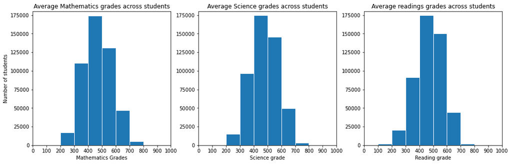

## (Visualization 2)

> YWhen I compared between math results for OECD and non OECD for math subject, It was clear that students perform better on OECD countries. Number of students in OECD who achieved between 400 and 600 are above 20000 students, while number of students in non-OECD hardly reached 15000. Number of student between 600 and 700 were much higher in OECD countries

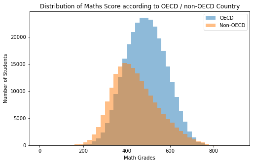

## (Visualization 3)

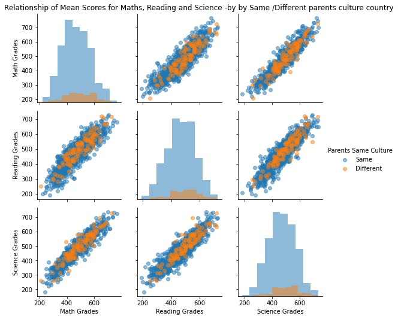

[output not shown]